# Predicting Housing Price

Name: Ng Yu Hang  
Admin Number: [student-id]  
Class: DAAA/FT/1B/07

# Project Objective

Create a supervised regression model to predict housing prices using the given datas

# Background

The provided dataset is to predict the housing prices in US based on various information, such as Region, House Size, Renovation status, etc.

# Research

From some quick research, I can determine that factors such as the **location, usable space, condition and local market** are some of the most important factors contributing to housing prices. We can see if we can feature engineer any of these information out from the information we have from the dataset.

Website reference: https://www.opendoor.com/articles/factors-that-influence-home-value

# Phases

1. Importing data (read csv file)
2. Data Preparation, Data Exploration and Feature Engineering
3. Model Preparation and model improvement
4. Running the models and finding the best model and hyperparameters
5. Checking if our models run better with the removed features
6. Comparing our best model to the baseline model
7. Overfitting reliability check

# Importing necessary libraries

```python
import pandas as pd
import matplotlib.pyplot as plt
import seaborn as sns
import numpy as np
from sklearn.model_selection import train_test_split, KFold, GridSearchCV, cross_val_score
from sklearn.preprocessing import StandardScaler, OneHotEncoder
from sklearn.compose import ColumnTransformer
from sklearn.linear_model import LinearRegression, Ridge, Lasso
from sklearn.pipeline import Pipeline
from sklearn.metrics import mean_squared_error, r2_score, mean_absolute_error
from sklearn.tree import DecisionTreeRegressor
from sklearn.ensemble import RandomForestRegressor, GradientBoostingRegressor, AdaBoostRegressor
from sklearn.svm import SVR
import warnings
from sklearn.dummy import DummyRegressor

warnings.filterwarnings("ignore")
warnings.filterwarnings("ignore", category=FutureWarning)
```

# Phase 1: Importing Data (read csv file)

## Importing the csv file

```python
data = pd.read_csv('housing_price_data.csv')
data.head(15)
```

|  | House ID | City | House Area (sqm) | No. of Bedrooms | No. of Toilets | Stories | Renovation Status | Price ($) |
| --- | --- | --- | --- | --- | --- | --- | --- | --- |
| 0 | 0 | Chicago | 742.0 | 4 | 2 | 3 | furnished | 1330000 |
| 1 | 1 | Denver | 896.0 | 4 | 4 | 4 | furnished | 1225000 |
| 2 | 2 | Chicago | 996.0 | 3 | 2 | 2 | semi-furnished | 1225000 |
| 3 | 3 | Seattle | 750.0 | 4 | 2 | 2 | furnished | 1221500 |
| 4 | 4 | New York | 742.0 | 4 | 1 | 2 | furnished | 1141000 |
| 5 | 5 | Boston | 750.0 | 3 | 3 | 1 | semi-furnished | 1085000 |
| 6 | 6 | Denver | 858.0 | 4 | 3 | 4 | semi-furnished | 1015000 |
| 7 | 7 | New York | 1620.0 | 5 | 3 | 2 | unfurnished | 1015000 |
| 8 | 8 | Denver | 810.0 | 4 | 1 | 2 | furnished | 987000 |
| 9 | 9 | Seattle | 575.0 | 3 | 2 | 4 | unfurnished | 980000 |
| 10 | 10 | Boston | 1320.0 | 3 | 1 | 2 | furnished | 980000 |
| 11 | 11 | Boston | 600.0 | 4 | 3 | 2 | semi-furnished | 968100 |
| 12 | 12 | Seattle | 655.0 | 4 | 2 | 2 | semi-furnished | 931000 |
| 13 | 13 | Boston | 350.0 | 4 | 2 | 2 | furnished | 924000 |
| 14 | 14 | Chicago | 780.0 | 3 | 2 | 2 | semi-furnished | 924000 |

# Phase 2: Data Preparation, Data Exploration and Feature Engineering

### Selecting Feature columns and separating them into numerical and categorical

```python
categorical_features = ['City', 'Renovation Status']
numerical_features = ['House Area (sqm)', 'No. of Bedrooms', 'No. of Toilets', 'Stories']
```

## Data Exploration: Describing the dataset

```python
data.describe().style.background_gradient(cmap="Purples")
```

| Â | House ID | House Area (sqm) | No. of Bedrooms | No. of Toilets | Stories | Price ($) |
| --- | --- | --- | --- | --- | --- | --- |
| count | 545.000000 | 545.000000 | 545.000000 | 545.000000 | 545.000000 | 545.000000 |
| mean | 272.000000 | 515.054128 | 2.965138 | 1.286239 | 1.805505 | 476672.924771 |
| std | 157.472220 | 217.014102 | 0.738064 | 0.502470 | 0.867492 | 187043.961566 |
| min | 0.000000 | 165.000000 | 1.000000 | 1.000000 | 1.000000 | 175000.000000 |
| 25% | 136.000000 | 360.000000 | 2.000000 | 1.000000 | 1.000000 | 343000.000000 |
| 50% | 272.000000 | 460.000000 | 3.000000 | 1.000000 | 2.000000 | 434000.000000 |
| 75% | 408.000000 | 636.000000 | 3.000000 | 2.000000 | 2.000000 | 574000.000000 |
| max | 544.000000 | 1620.000000 | 6.000000 | 4.000000 | 4.000000 | 1330000.000000 |

### Check if there's missing data

```python
data.isnull().sum()
```

```
House ID             0
City                 0
House Area (sqm)     0
No. of Bedrooms      0
No. of Toilets       0
Stories              0
Renovation Status    0
Price ($)            0
dtype: int64
```

This tells us that this is a fully populated dataset, with no missing data, hence no need for dropping missing rows or imputing any data

### General overview of numerical features

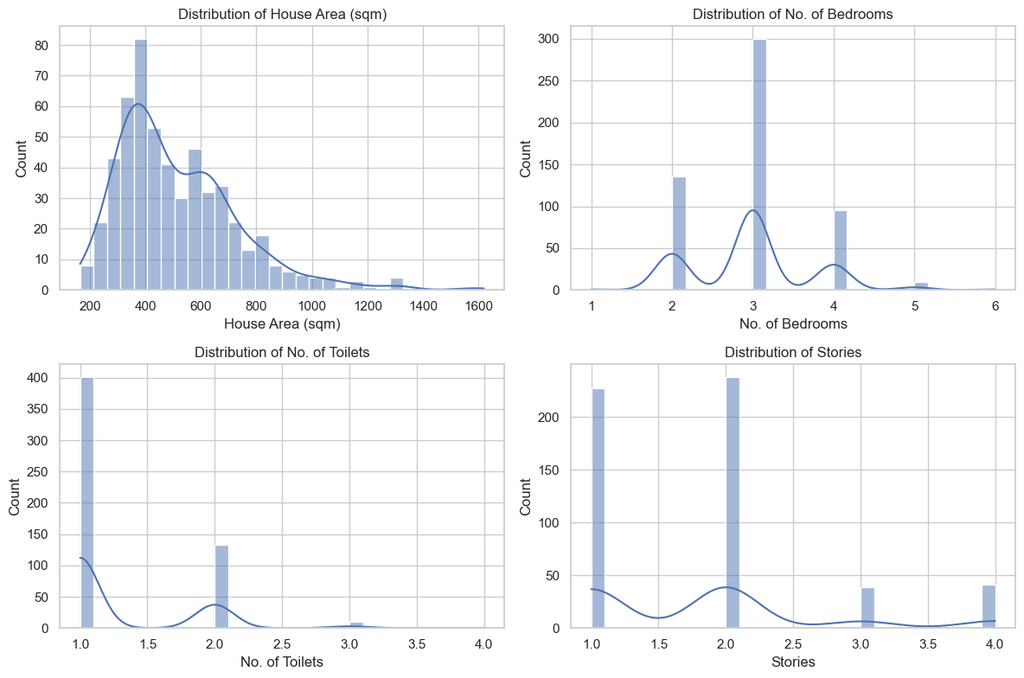

```python
plt.figure(figsize=(12, 8))
for i, column in enumerate(numerical_features):
    plt.subplot(2, 2, i + 1)
    sns.histplot(data[column], kde=True, bins=30)
    plt.title(f'Distribution of {column}')
plt.tight_layout()
plt.show()
```

From this, we can see tha the majority of the House Area is around `400sqm`, with `3 bedrooms`, `1 toilet`, and `2 stories`.

### General overview of Categorical Features

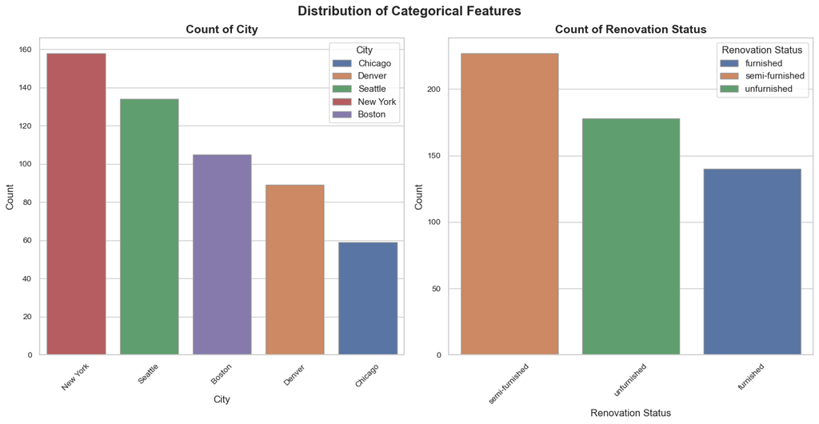

```python
sns.set_theme(style="whitegrid")
plt.figure(figsize=(14, 7))
for i, column in enumerate(categorical_features):
    plt.subplot(1, 2, i + 1)
    sns.countplot(
        data=data,
        x=column,
        order=data[column].value_counts().index,
        hue=column,
        legend=True,
        edgecolor=".6"
    )
    plt.title(f'Count of {column}', fontsize=14, fontweight='bold')
    plt.xlabel(column, fontsize=12)
    plt.ylabel('Count', fontsize=12)
    plt.xticks(rotation=45, fontsize=10)
    plt.yticks(fontsize=10)
plt.tight_layout()
plt.suptitle("Distribution of Categorical Features", fontsize=16, fontweight='bold', y=1.02)
plt.show()
```

From this, we can see thst most of the houses in this dataset are in `New York`, and most of them are `semi-furnished`

### Correlation heatmap

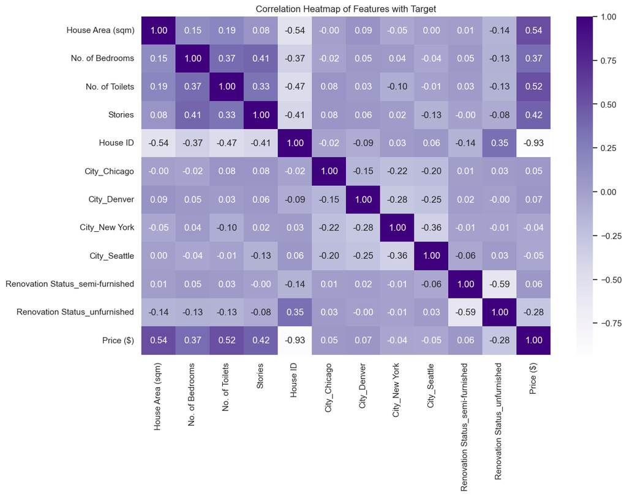

```python
data_dummies = pd.get_dummies(data, columns=categorical_features, drop_first=True)

correlation_features = numerical_features + [col for col in data_dummies.columns if col not in numerical_features and col != 'Price ($)'] + ['Price ($)']
correlation_matrix = data_dummies[correlation_features].corr()

plt.figure(figsize=(12, 8))
sns.heatmap(correlation_matrix, annot=True, cmap='Purples', fmt='.2f', cbar=True)
plt.title('Correlation Heatmap of Features with Target')
plt.show()
```

### Relationship Scatterplot

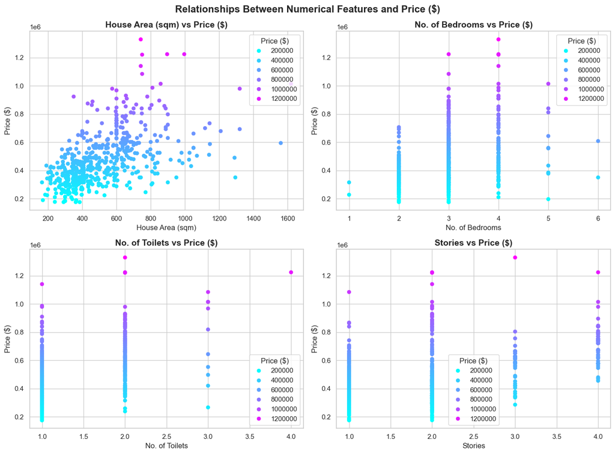

```python
sns.set_theme(style="whitegrid")
plt.figure(figsize=(14, 10))

for i, column in enumerate(numerical_features):
    plt.subplot(2, 2, i + 1)
    sns.scatterplot(
        data=data,
        x=column,
        y='Price ($)',
        hue='Price ($)',
        palette='cool',
        alpha=1,
        edgecolor=None
    )
    plt.title(f'{column} vs Price ($)', fontsize=14, fontweight='bold')
    plt.xlabel(column, fontsize=12)
    plt.ylabel('Price ($)', fontsize=12)

plt.tight_layout()
plt.suptitle("Relationships Between Numerical Features and Price ($)", fontsize=16, fontweight='bold', y=1.02)
plt.show()
```

From this, we can tell there is a positive correlation between `House Area` and `Price`, where the larger the House Area, the higher the Price. While for No. of Bedrooms vs price, there isnt a very clear trend of increasing price, with houses with 3-4 bedrooms spanning across a wide range of prices.  
The number of toilets vs price plot shows that houses with more toilets are generally higher priced, and it seems that most houses have 1 or 2 toilets.  
Houses with more stories (3-4) are generally priced higher, and most houses have `2 stories`.

## Finding other useful features by feature engineering

#### We will create more features and plot them on a correlation heatmap to see how much our target variable is correlated to it

From the research we have done, factors that we could get from this dataset could be the `condition` (aka renovation status), and `Total Livable Area`. We will feature engineer this, along with some other ratios to increase the model's performance by providing more features so it can try to catch some complex relationship

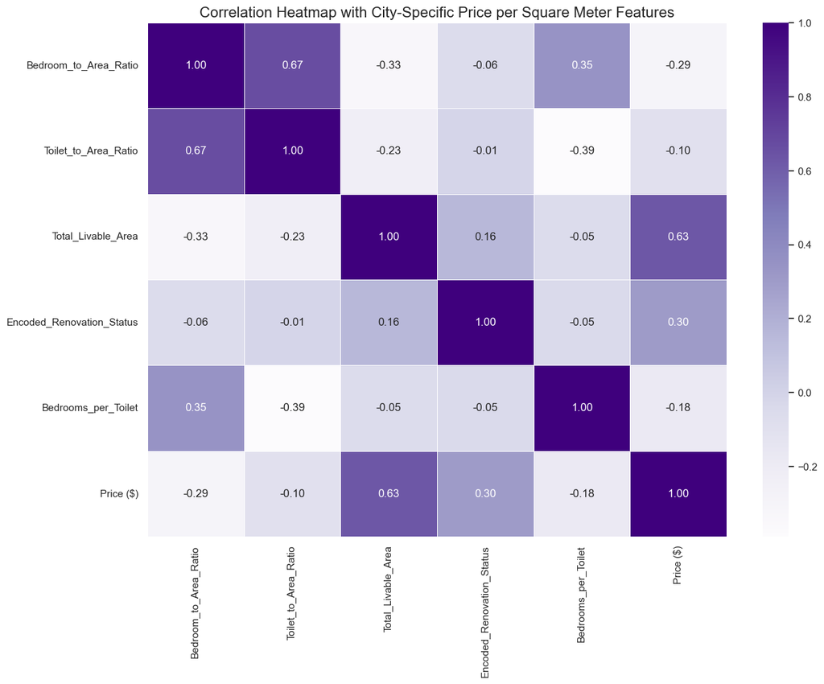

```python
data['Bedroom_to_Area_Ratio'] = data['No. of Bedrooms'] / data['House Area (sqm)']
data['Toilet_to_Area_Ratio'] = data['No. of Toilets'] / data['House Area (sqm)']
data['Total_Livable_Area'] = data['House Area (sqm)'] * data['Stories']
renovation_map = {'unfurnished': 0, 'semi-furnished': 1, 'furnished': 2}
data['Encoded_Renovation_Status'] = data['Renovation Status'].map(renovation_map)
data['Bedrooms_per_Toilet'] = data['No. of Bedrooms'] / data['No. of Toilets']


correlation_feature_columns = [
    'Bedroom_to_Area_Ratio', 'Toilet_to_Area_Ratio',
    'Total_Livable_Area', 'Encoded_Renovation_Status', 'Bedrooms_per_Toilet'
]

plt.figure(figsize=(14, 10))
newcorrelation_matrix = data[correlation_feature_columns + ['Price ($)']].corr()
sns.heatmap(newcorrelation_matrix, annot=True, cmap='Purples', fmt='.2f', linewidths=0.5)
plt.title('Correlation Heatmap with City-Specific Price per Square Meter Features', fontsize=16)
plt.show()
```

### Final Feature Selection

We make the final selection of features, including our additional feature engineered features which may provide value to training our model.

```python
numerical_features  = numerical_features + [
    'Encoded_Renovation_Status', 'Bedroom_to_Area_Ratio',
    'Total_Livable_Area', 'Bedrooms_per_Toilet'
]

feature_columns = numerical_features + categorical_features
```

## Data Preparation

```python
target = 'Price ($)'
y = data[target]
X = data[feature_columns]
X.head()
```

|  | House Area (sqm) | No. of Bedrooms | No. of Toilets | Stories | Encoded_Renovation_Status | Bedroom_to_Area_Ratio | Total_Livable_Area | Bedrooms_per_Toilet | City | Renovation Status |
| --- | --- | --- | --- | --- | --- | --- | --- | --- | --- | --- |
| 0 | 742.0 | 4 | 2 | 3 | 2 | 0.005391 | 2226.0 | 2.0 | Chicago | furnished |
| 1 | 896.0 | 4 | 4 | 4 | 2 | 0.004464 | 3584.0 | 1.0 | Denver | furnished |
| 2 | 996.0 | 3 | 2 | 2 | 1 | 0.003012 | 1992.0 | 1.5 | Chicago | semi-furnished |
| 3 | 750.0 | 4 | 2 | 2 | 2 | 0.005333 | 1500.0 | 2.0 | Seattle | furnished |
| 4 | 742.0 | 4 | 1 | 2 | 2 | 0.005391 | 1484.0 | 4.0 | New York | furnished |

Here, we set our y to contain the `target data` and our X to contain the `feature datas`.

The above shows the first 5 rows of our X data to see which columns are present in our X dataset

## Train-Test Split data

```python
X_train, X_test, y_train, y_test = train_test_split(X, y, test_size=0.3, random_state=42)

print("Training set size:", X_train.shape)
print("Testing set size:", X_test.shape)

X_train = X_train.reset_index(drop=True)
X_test = X_test.reset_index(drop=True)
y_train = y_train.reset_index(drop=True)
y_test = y_test.reset_index(drop=True)
```

```
Training set size: (381, 10)
Testing set size: (164, 10)
```

This shows the number of rows and columns we have in each set.

## Preprocessing

```python
numerical_preprocessor = Pipeline([
    ('scaler', StandardScaler())
])

categorical_preprocessor = Pipeline([
    ('onehot', OneHotEncoder(drop='first'))
])

preprocessor = ColumnTransformer([
    ('num', numerical_preprocessor, numerical_features),
    ('cat', categorical_preprocessor, categorical_features)
])
```

`StandardScaler` scales numerical features to have a mean of 0, and a standard deviation of 1. This helps with improving many models' performance.

`OneHotEncoder` is used on categorical data to create numerical data by creating binary columns.

(drop='first') is used for dropping the first column in the OneHotEncoder binary column to create redundancy (for instance, if there are 3 categories, if 2 columns of the categories are 0, it just means its the 3rd category)

# Phase 3: Preparing our Models

## Setting the hyperparameters to tune our models

```python
param_grids = {
    'Linear Regression': {},

    'Ridge': {
        'ridge__alpha': [0.1, 1.0, 10.0],
        'ridge__solver': ['auto', 'svd', 'saga']
    },

    'Lasso': {
        'lasso__alpha': [0.01, 0.1, 1.0],
        'lasso__max_iter': [5000, 10000, 20000]
    },

    'Decision Tree': {
        'dt__max_depth': [6, 10, None],
        'dt__min_samples_split': [2, 5, 10],
        'dt__min_samples_leaf': [1, 3, 5]
    },

    'Random Forest': {
        'forest__n_estimators': [75, 100, 150],
        'forest__max_depth': [10, 15, None],
        'forest__min_samples_split': [2, 5, 10]
    },

    'Gradient Boosting': {
        'gb__n_estimators': [100, 150, 200],
        'gb__learning_rate': [0.03, 0.05, 0.1],
        'gb__max_depth': [3, 5, 7]
    },

    'AdaBoost': {
        'ab__n_estimators': [75, 100, 150],
        'ab__learning_rate': [0.03, 0.1, 0.2]
    },

    'SVR': {
        'svr__C': [1.0, 10.0, 50.0],
        'svr__epsilon': [0.01, 0.1, 0.5],
        'svr__kernel': ['linear', 'rbf']
    }
}
```

As the hyperparameters show, for this dataset, I chose a rather `balanced` approach.

As this is a regression task to predict housing prices, having a model that doesn't overfit too much to outliers and doesn't underfit to the point it couldn't capture patterns is key to making a good model for this task.

## Defining our models with pipeline to include our hyperparameter tuning and preprocessors

```python
models = {
    'Linear Regression': Pipeline([
        ('preprocessor', preprocessor),
        ('linear', LinearRegression())
    ]),
    'Ridge': Pipeline([
        ('preprocessor', preprocessor),
        ('ridge', Ridge())
    ]),
    'Lasso': Pipeline([
        ('preprocessor', preprocessor),
        ('lasso', Lasso(alpha=10, max_iter=200000))
    ]),
    'Decision Tree': Pipeline([
        ('preprocessor', preprocessor),
        ('dt', DecisionTreeRegressor())
    ]),
    'Random Forest': Pipeline([
        ('preprocessor', preprocessor),
        ('forest', RandomForestRegressor(random_state=42))
    ]),
    'Gradient Boosting': Pipeline([
        ('preprocessor', preprocessor),
        ('gb', GradientBoostingRegressor(random_state=42))
    ]),
    'AdaBoost': Pipeline([
        ('preprocessor', preprocessor),
        ('ab', AdaBoostRegressor(random_state=42))
    ]),
    'SVR': Pipeline([
        ('preprocessor', preprocessor),
        ('svr', SVR())
    ])
}
```

Using pipeline, I can link the models to use the respective data processing methods using the previously defined preprocessors. Pipelines make the code cleaner and easier to make changes to, as well as make sure the same transformations are consistently applied to both train and test data, preventing Data Leakage.

## Setting up our KFolds

```python
kf = KFold(n_splits=5, shuffle=True, random_state=42)
```

# Phase 4: Feature Importance and Model Performance Test

## Feature Importance of models that support it

```
Model: Decision Tree
```

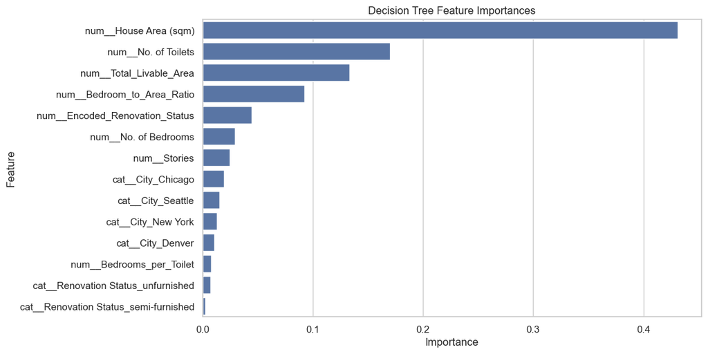

```
Model: Random Forest
```

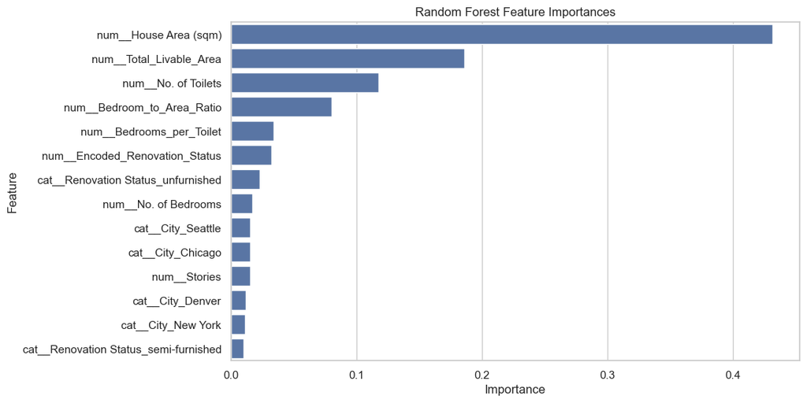

```
Model: Gradient Boosting
```

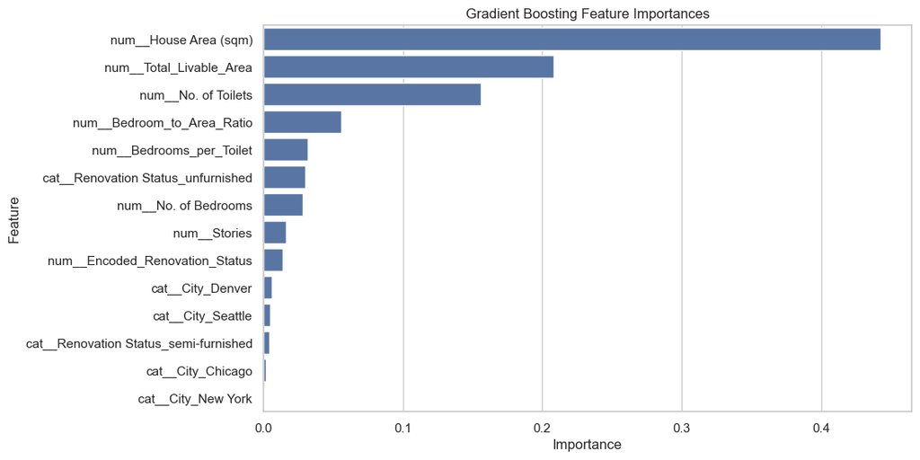

```
Model: AdaBoost
```

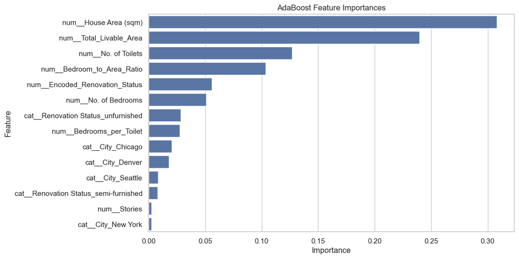

```python
for model_name, pipeline in models.items():
    pipeline.fit(X_train, y_train)
    best_model = pipeline
    preprocessor = best_model.named_steps.get('preprocessor', None)
    model_step_name = list(best_model.named_steps.keys())[-1]
    model = best_model.named_steps[model_step_name]

    # Check if the model supports feature_importances_
    if hasattr(model, 'feature_importances_'):
        print(f"Model: {model_name}")
        feature_importances = model.feature_importances_
        feature_names = preprocessor.get_feature_names_out()
        feature_importance_df = pd.DataFrame({
            'Feature': feature_names,
            'Importance': feature_importances
        }).sort_values(by='Importance', ascending=False)

        # Plot feature importances
        plt.figure(figsize=(10, 6))
        sns.barplot(x='Importance', y='Feature', data=feature_importance_df)
        plt.title(f'{model_name} Feature Importances')
        plt.show()
```

From the feature importance plots, we can see that the City feature and furnished feature doesn't seem very important to the models. Hence we can try removing them to see if we get better results.

## Running the models

```python
results = {}

for model_name, pipeline in models.items():
    print(f"Training {model_name}...")

    grid = GridSearchCV(pipeline, param_grid=param_grids[model_name], cv=kf, scoring='neg_mean_squared_error', verbose=2)
    grid.fit(X_train, y_train)

    best_model = grid.best_estimator_
    y_pred = best_model.predict(X_test)


    mae = mean_absolute_error(y_test, y_pred)
    mse = mean_squared_error(y_test, y_pred)
    rmse = np.sqrt(mse)
    r2 = r2_score(y_test, y_pred)
    mape = np.mean(np.abs((y_test - y_pred) / y_test)) * 100

    results[model_name] = {
        'Best Parameters': grid.best_params_,
        'MAE': mae,
        'MSE': mse,
        'RMSE': rmse,
        'RÂ²': r2,
        'MAPE': mape
    }
```

[output not shown]

[output cut: 596 more lines]

[output not shown]

Like the partA, i have used the `verbose = (number)` method to output all the folds to show us that our models are still being trained and the process has not froze

## Performance Result

```python
results_df = pd.DataFrame(results).T

results_df = results_df.style.apply(
    lambda x: [
        "background-color: green; color: white" if v == x.min() else
        "background-color: red; color: white" if v == x.max() else ""
        for v in x
    ],
    subset=['MAE', 'MSE', 'MAPE', 'RMSE']
).apply(
    lambda x: [
        "background-color: green; color: white" if v == x.max() else
        "background-color: red; color: white" if v == x.min() else ""
        for v in x
    ],
    subset=['RÂ²']
)

print("Model Evaluation Results:\n")
print("Legend: \nGreen - Best Performance; Red - Worst Performance")
results_df
```

```
Model Evaluation Results:

Legend:
Green - Best Performance; Red - Worst Performance
```

| Â | Best Parameters | MAE | MSE | RMSE | RÂ² | MAPE |
| --- | --- | --- | --- | --- | --- | --- |
| Linear Regression | {} | 107461.711389 | 20802324776.557007 | 144230.110506 | 0.516943 | 25.072803 |
| Ridge | {'ridge__alpha': 10.0, 'ridge__solver': 'saga'} | 106747.303813 | 20489704238.558136 | 143142.251759 | 0.524202 | 24.895262 |
| Lasso | {'lasso__alpha': 1.0, 'lasso__max_iter': 5000} | 107459.957764 | 20801775408.507088 | 144228.206009 | 0.516956 | 25.072436 |
| Decision Tree | {'dt__max_depth': 6, 'dt__min_samples_leaf': 5, 'dt__min_samples_split': 2} | 108373.900655 | 22216616604.062397 | 149052.395499 | 0.484101 | 25.352562 |
| Random Forest | {'forest__max_depth': 10, 'forest__min_samples_split': 10, 'forest__n_estimators': 100} | 106367.971448 | 21352094295.873825 | 146123.558319 | 0.504177 | 24.802835 |
| Gradient Boosting | {'gb__learning_rate': 0.03, 'gb__max_depth': 3, 'gb__n_estimators': 150} | 107659.263578 | 21273643419.498463 | 145854.871086 | 0.505998 | 25.398451 |
| AdaBoost | {'ab__learning_rate': 0.03, 'ab__n_estimators': 150} | 114049.023620 | 22634827830.904278 | 150448.754833 | 0.474390 | 27.638326 |
| SVR | {'svr__C': 50.0, 'svr__epsilon': 0.01, 'svr__kernel': 'linear'} | 141807.217940 | 35706922472.160217 | 188962.754193 | 0.170839 | 32.447890 |

In conclusion from this evaluation, `Ridge Regression` is our best model, and `SVR` is our worst model

## Selecting the best models, parameters and trying less features for this task

```python
feature_columns
```

```
['House Area (sqm)',
 'No. of Bedrooms',
 'No. of Toilets',
 'Stories',
 'Encoded_Renovation_Status',
 'Bedroom_to_Area_Ratio',
 'Total_Livable_Area',
 'Bedrooms_per_Toilet',
 'City',
 'Renovation Status']
```

This shows us our current features

```python
columns_to_drop = ['City', 'Renovation Status', 'Stories']

# Update feature_columns by removing the specified columns
newfeature_columns = [feature for feature in feature_columns if feature not in columns_to_drop]
newfeature_columns
```

```
['House Area (sqm)',
 'No. of Bedrooms',
 'No. of Toilets',
 'Encoded_Renovation_Status',
 'Bedroom_to_Area_Ratio',
 'Total_Livable_Area',
 'Bedrooms_per_Toilet']
```

### Removing the unnecessary features from what the feature importance showed

```python
tuned_X = data[newfeature_columns]

tuned_X_train, tuned_X_test, tuned_y_train, tuned_y_test = train_test_split(tuned_X, y, test_size=0.3, random_state=42)

print("Training set size:", X_train.shape)
print("Testing set size:", X_test.shape)

tuned_X_train = tuned_X_train.reset_index(drop=True)
tuned_X_test = tuned_X_test.reset_index(drop=True)
tuned_y_train = tuned_y_train.reset_index(drop=True)
tuned_y_test = tuned_y_test.reset_index(drop=True)
```

```
Training set size: (381, 10)
Testing set size: (164, 10)
```

### Defining our new models with the best parameters

```python
newpreprocessor = ColumnTransformer([
    ('num', numerical_preprocessor, newfeature_columns)
])
```

There are no more categorical features after we removed cities, so we can just use the feature columns for preprocessing

```python
newparam_grids = {
    'Linear Regression': {},
    'Ridge': {
        'ridge__alpha': 10,
        'ridge__solver': 'auto'
    },
    'Random Forest': {
        'forest__max_depth': [10],
        'forest__min_samples_split': [10],
        'forest__n_estimators': [100]
    }
}
```

```python
best_models = {
    'Linear Regression': Pipeline([
        ('preprocessor', newpreprocessor),
        ('linear', LinearRegression())
    ]),
    'Ridge': Pipeline([
        ('preprocessor', newpreprocessor),
        ('ridge', Ridge())
    ]),
    'Random Forest': Pipeline([
        ('preprocessor', newpreprocessor),
        ('forest', RandomForestRegressor(random_state=42))
    ]),
}
```

Pipelining our newpreprocessor with the best models only

## Our new feature importances for the rest of the features

```python
for model_name, pipeline in best_models.items():
    best_model = pipeline
    preprocessor = best_model.named_steps['preprocessor']
    model_step_name = list(best_model.named_steps.keys())[-1]
    model = best_model.named_steps[model_step_name]

    if hasattr(model, 'feature_importances_'):
        feature_importances = model.feature_importances_
        feature_names = preprocessor.get_feature_names_out()
        feature_importance_df = pd.DataFrame({
            'Feature': feature_names,
            'Importance': feature_importances
        }).sort_values(by='Importance', ascending=True)

        plt.figure(figsize=(10, 6))
        sns.barplot(x='Importance', y='Feature', data=feature_importance_df)
        plt.title(f'{model_name} Feature Importances')
        plt.xlabel("Feature Importance")
        plt.ylabel("Features")
        plt.tight_layout()
        plt.show()
```

[output not shown]

We are now left with data that were somewhat useful to very useful to most of the models with feature importance.

# Phase 5: Checking if our models run better with the removed features

## Training our models with the best hyperparameters

```python
tuned_results = {}

for model_name, pipeline in best_models.items():
    print(f"\nTraining and evaluating model: {model_name}\n")

    cv_scores = cross_val_score(
        pipeline,
        tuned_X_train,
        tuned_y_train,
        cv=kf,
        scoring='neg_mean_squared_error',
        verbose=3
    )

    pipeline.fit(tuned_X_train, tuned_y_train)
    tuned_y_pred = pipeline.predict(tuned_X_test)

    mae = mean_absolute_error(tuned_y_test, tuned_y_pred)
    mse = mean_squared_error(tuned_y_test, tuned_y_pred)
    rmse = np.sqrt(mse)
    r2 = r2_score(tuned_y_test, tuned_y_pred)
    mape = np.mean(np.abs((tuned_y_test - tuned_y_pred) / tuned_y_test)) * 100

    tuned_results[model_name] = {
        'MAE': mae,
        'MSE': mse,
        'RMSE': rmse,
        'RÂ²': r2,
        'MAPE': mape
    }
```

```
Training and evaluating model: Linear Regression

[CV] END ..................... score: (test=-11050931141.053) total time=   0.0s
[CV] END ..................... score: (test=-15999429033.876) total time=   0.0s
[CV] END ..................... score: (test=-15654523571.794) total time=   0.0s
[CV] END ..................... score: (test=-15007708800.022) total time=   0.0s
[CV] END ...................... score: (test=-9228069389.528) total time=   0.0s

Training and evaluating model: Ridge

[CV] END ..................... score: (test=-10991619338.281) total time=   0.0s
[CV] END ..................... score: (test=-15999227342.490) total time=   0.0s
[CV] END ..................... score: (test=-15692776292.479) total time=   0.0s
[CV] END ..................... score: (test=-14979685879.774) total time=   0.0s
[CV] END ...................... score: (test=-9182763171.309) total time=   0.0s

Training and evaluating model: Random Forest

[CV] END ..................... score: (test=-12416140638.698) total time=   0.0s
[CV] END ..................... score: (test=-18744753506.187) total time=   0.0s
[CV] END ..................... score: (test=-18429221216.306) total time=   0.0s
[CV] END ..................... score: (test=-20373891030.662) total time=   0.0s
[CV] END ..................... score: (test=-12420917477.493) total time=   0.0s
```

## Display Results of our tuned models

```python
tuned_results_df = pd.DataFrame(tuned_results).T

tuned_results_df = tuned_results_df.style.apply(
    lambda x: [
        "background-color: green; color: white" if v == x.min() else
        "background-color: red; color: white" if v == x.max() else ""
        for v in x
    ],
    subset=['MAE', 'MSE', 'MAPE', 'RMSE']
).apply(
    lambda x: [
        "background-color: green; color: white" if v == x.max() else
        "background-color: red; color: white" if v == x.min() else ""
        for v in x
    ],
    subset=['RÂ²']
)

print("Model Evaluation Results:\n")
print("Legend: \nGreen - Best Performance; Red - Worst Performance")
tuned_results_df
```

```
Model Evaluation Results:

Legend:
Green - Best Performance; Red - Worst Performance
```

| Â | MAE | MSE | RMSE | RÂ² | MAPE |
| --- | --- | --- | --- | --- | --- |
| Linear Regression | 106478.194817 | 20562362632.338398 | 143395.825017 | 0.522515 | 25.008845 |
| Ridge | 106447.500791 | 20525450480.007473 | 143267.059996 | 0.523372 | 24.991854 |
| Random Forest | 109459.561606 | 22613652902.651436 | 150378.365807 | 0.474882 | 25.309923 |

From this, we can tell that `Ridge` still remains the best model, outperforming every other models. Hence, `Ridge` is the most suitable model for this task.

### Full Feature VS Removed Feature

```python
results_df = pd.DataFrame(results).T
results_df = results_df.drop(columns=["Best Parameters"], errors='ignore')
tuned_results_df = pd.DataFrame(tuned_results).T


models_to_compare = tuned_results_df.index
comparison_df = results_df.loc[models_to_compare] - tuned_results_df


comparison_df = comparison_df.style.apply(
    lambda x: [
        "background-color: green; color: white" if v > 0 else
        "background-color: red; color: white"
        for v in x
    ],
    subset=['MAE', 'MSE', 'MAPE', 'RMSE']
).apply(
    lambda x: [
        "background-color: green; color: white" if v < 0 else
        "background-color: red; color: white"
        for v in x
    ],
    subset=['RÂ²']
)

print("Green = improvement, red = decreased performance")

comparison_df
```

```
Green = improvement, red = decreased performance
```

| Â | MAE | MSE | RMSE | RÂ² | MAPE |
| --- | --- | --- | --- | --- | --- |
| Linear Regression | 983.516572 | 239962144.218609 | 834.285489 | -0.005572 | 0.063958 |
| Ridge | 299.803022 | -35746241.449337 | -124.808238 | 0.000830 | -0.096592 |
| Random Forest | -3091.590158 | -1261558606.777611 | -4254.807487 | 0.029295 | -0.507088 |

# Phase 6: Comparing our best model with best features to a baseline dummy model

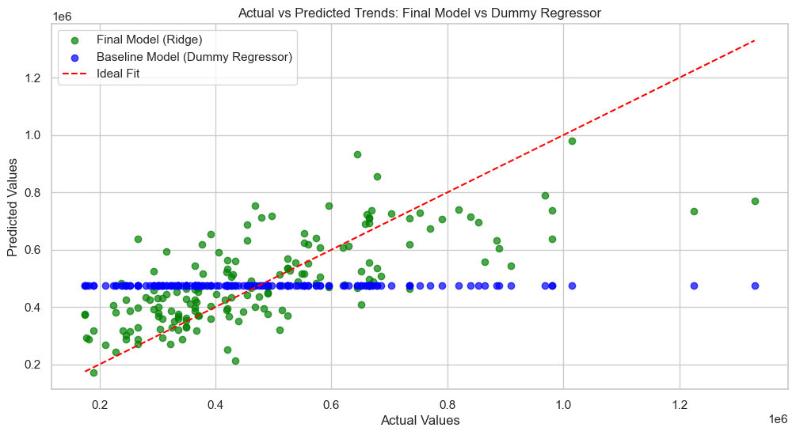

```python
# Fit a Dummy Regressor
dummy_model = DummyRegressor(strategy="mean")
dummy_model.fit(X_train, y_train)
dummy_predictions = dummy_model.predict(X_test)

# Final model predictions
final_model = best_models['Ridge']
final_predictions = final_model.predict(X_test)

# Plot Actual vs Predicted Trends
plt.figure(figsize=(12, 6))

plt.scatter(y_test, final_predictions, label="Final Model (Ridge)", alpha=0.7, color='green')
plt.scatter(y_test, dummy_predictions, label="Baseline Model (Dummy Regressor)", alpha=0.7, color='blue')
plt.plot([min(y_test), max(y_test)], [min(y_test), max(y_test)],
         color='red', linestyle='--', label="Ideal Fit")

plt.title("Actual vs Predicted Trends: Final Model vs Dummy Regressor")
plt.xlabel("Actual Values")
plt.ylabel("Predicted Values")
plt.legend()
plt.grid(True)
plt.show()
```

From this, we can see that our final model, `Ridge` has more plots closer to the ideal fit line, compared to our baseline model, hence showing that our final model is better than the baseline dummy model

```python
mae = mean_absolute_error(y_test, dummy_predictions)
mse = mean_squared_error(y_test, dummy_predictions)
rmse = np.sqrt(mse)
r2 = r2_score(y_test, dummy_predictions)
mape = np.mean(np.abs((y_test - dummy_predictions) / y_test)) * 100

final_mae = mean_absolute_error(y_test, final_predictions)
final_mse = mean_squared_error(y_test, final_predictions)
final_rmse = np.sqrt(final_mse)
final_r2 = r2_score(y_test, final_predictions)
final_mape = np.mean(np.abs((y_test - final_predictions) / y_test)) * 100

dummy_results = {
    'MAE': mae,
    'MSE': mse,
    'RMSE': rmse,
    'RÂ²': r2,
    'MAPE': mape,
}

final_results = {
    'MAE': final_mae,
    'MSE': final_mse,
    'RMSE': final_rmse,
    'RÂ²': final_r2,
    'MAPE': final_mape,
}

dummy_results_df = pd.DataFrame(dummy_results, index=["Dummy Model"]).T
dummy_results_df.columns = ["Dummy Model"]

combined_results = pd.DataFrame({
    "Dummy Model": dummy_results,
    "Final Model (Ridge)": final_results
}).T

combined_results_df = combined_results.style.apply(
    lambda x: [
        "background-color: green; color: white" if v == x.min() else
        "background-color: red; color: white" if v == x.max() else ""
        for v in x
    ],
    subset=['MAE', 'MSE', 'RMSE', 'MAPE']
).apply(
    lambda x: [
        "background-color: green; color: white" if v == x.max() else
        "background-color: red; color: white" if v == x.min() else ""
        for v in x
    ],
    subset=['RÂ²']
)
combined_results_df
```

| Â | MAE | MSE | RMSE | RÂ² | MAPE |
| --- | --- | --- | --- | --- | --- |
| Dummy Model | 161771.174173 | 43065975934.607613 | 207523.434664 | -0.000048 | 39.536136 |
| Final Model (Ridge) | 106447.500791 | 20525450480.007473 | 143267.059996 | 0.523372 | 24.991854 |

To better view our model's superior performance comapred to the Dummy model, I have created a table to better visualize and compare their differences.

# Final Phase: Overfitting Reliability Check

As a final check before we conclude the assignment, we want to make sure our model is actually reliable, and not overfitting, giving a misleading result. Hence we will compare the difference between the `Train R2 score` vs `Test R2 Score` to determine if they're overfitting.

```python
ridge_model = models['Ridge']
best_params = newparam_grids['Ridge']

ridge_model.set_params(**best_params)
ridge_model.fit(X_train, y_train)


train_predictions = ridge_model.predict(X_train)
test_predictions = ridge_model.predict(X_test)
train_r2 = r2_score(y_train, train_predictions)
test_r2 = r2_score(y_test, test_predictions)

train_test_results = {
    'Train RÂ²': train_r2,
    'Test RÂ²': test_r2
}
overfitting = train_r2 - test_r2

print(f"Model: Ridge")
print(f"Train RÂ²: {train_r2:.4f}")
print(f"Test RÂ²: {test_r2:.4f}\n")
print(f"Overfitting test (Train RÂ² - Test RÂ²): {overfitting:.4f}\n")

if overfitting > 0.1:
    print("Conclusion: This model might be overfitting.")
elif train_r2 < 0.3 and test_r2 < 0.3:
    print("Conclusion: This model might be underfitting.")
else:
    print("Conclusion: No overfitting or underfitting detected. The model generalizes well.")
```

```
Model: Ridge
Train RÂ²: 0.5960
Test RÂ²: 0.5242

Overfitting test (Train RÂ² - Test RÂ²): 0.0718

Conclusion: No overfitting or underfitting detected. The model generalizes well.
```

From this test, we can see that our model is not overfitting, hence the result of it being the best performing model is `reliable`

## Conclusion

# QNA

âœ”ï¸ How is your prediction task defined? And what is the meaning of the output variable?

âžœ The task is a regression task to predict the house price (Price ($)) based on the features provided in the dataset as factors that it depends on.  
âžœ The output variable is `Price ($)`, which represents the price of the house in U.S. Dollars

âœ”ï¸Did you process the features in any way?

âžœ Yes, since this has no missing datas, I did not have to impute any data or drop any rows, hence I only used StandardScaler() for numerical features and OneHotEncoder for the categorical features for better model performance, and allow the models to be trained with them effectively.

For this task, i have also feature engineered new features to help the models catch more complex relationships between the features to perform better.

âœ”ï¸ How did you select which learning algorithms to use?

âžœ Since this is a regression problem, I have selected models that are made for regression problems. Also specifically adding Lasso and Ridge, as these 2 models have Regularization Penalties. It helps with reducing overfitting, as well as generalizing over noisy data. Noise datas are datas that are datas in the dataset that are irrelevant that can disrupt the pattern.

âœ”ï¸ Did you try to tune the hyperparameters of the learning algorithm, and how?

âžœ Yes, I used hyperparameters to set the complexity of the learning algorithms. Since this dataset has no extremely obvious class imbalances, I will be setting the hyperparameters to be fairly balanced in terms of underfitting and overfitting.

âœ”ï¸ How do you evaluate the quality of your machine learning models?

âœ”ï¸ How well does your system compare to a dummy baseline?

âžœ According to my scatterplot of Actual vs Predicted Trends, as well as my evaluation results, to which most of my models have better MAE, MSE, R^2, MAPE scores than the baseline dummy model. However, the dummy baseline assumes a constant and simplistic pattern and does not try to learn the pattern, hence any properly made model should be able to outperform this.

âœ”ï¸ Is it possible to say something about which features the model considers important? (Whether this is possible depends on the type of classifier you are using)